# Project: Explore and Summarize Data - Red Wine Quality

Gauthier Riou

6th June, 2018

## Overview of data set

This tidy data set contains 1,599 red wines with 11 variables describing chemical wine properties. At least 3 wine experts rated the quality of each wine, providing a rating between 0 (very bad) and 10 (very excellent).  
In all my study, my dependent variable will be the wine quality. All the other wine properties are considered independent variables analysed to try to predict wine quality.

```
##   X fixed.acidity volatile.acidity citric.acid residual.sugar chlorides
## 1 1           7.4             0.70        0.00            1.9     0.076
## 2 2           7.8             0.88        0.00            2.6     0.098
## 3 3           7.8             0.76        0.04            2.3     0.092
## 4 4          11.2             0.28        0.56            1.9     0.075
## 5 5           7.4             0.70        0.00            1.9     0.076
## 6 6           7.4             0.66        0.00            1.8     0.075
##   free.sulfur.dioxide total.sulfur.dioxide density   pH sulphates alcohol
## 1                  11                   34  0.9978 3.51      0.56     9.4
## 2                  25                   67  0.9968 3.20      0.68     9.8
## 3                  15                   54  0.9970 3.26      0.65     9.8
## 4                  17                   60  0.9980 3.16      0.58     9.8
## 5                  11                   34  0.9978 3.51      0.56     9.4
## 6                  13                   40  0.9978 3.51      0.56     9.4
##   quality
## 1       5
## 2       5
## 3       5
## 4       6
## 5       5
## 6       5
```

```
## 'data.frame':    1599 obs. of  13 variables:
##  $ X                   : int  1 2 3 4 5 6 7 8 9 10 ...
##  $ fixed.acidity       : num  7.4 7.8 7.8 11.2 7.4 7.4 7.9 7.3 7.8 7.5 ...
##  $ volatile.acidity    : num  0.7 0.88 0.76 0.28 0.7 0.66 0.6 0.65 0.58 0.5 ...
##  $ citric.acid         : num  0 0 0.04 0.56 0 0 0.06 0 0.02 0.36 ...
##  $ residual.sugar      : num  1.9 2.6 2.3 1.9 1.9 1.8 1.6 1.2 2 6.1 ...
##  $ chlorides           : num  0.076 0.098 0.092 0.075 0.076 0.075 0.069 0.065 0.073 0.071 ...
##  $ free.sulfur.dioxide : num  11 25 15 17 11 13 15 15 9 17 ...
##  $ total.sulfur.dioxide: num  34 67 54 60 34 40 59 21 18 102 ...
##  $ density             : num  0.998 0.997 0.997 0.998 0.998 ...
##  $ pH                  : num  3.51 3.2 3.26 3.16 3.51 3.51 3.3 3.39 3.36 3.35 ...
##  $ sulphates           : num  0.56 0.68 0.65 0.58 0.56 0.56 0.46 0.47 0.57 0.8 ...
##  $ alcohol             : num  9.4 9.8 9.8 9.8 9.4 9.4 9.4 10 9.5 10.5 ...
##  $ quality             : int  5 5 5 6 5 5 5 7 7 5 ...
```

The data is already in a convenient **tidy** format.  
X is the observation index.  
The variables are all listed in separate columns. They are measures of different wine properties for each X observation.  
Morevoer, all the variables are numericals (or “non categorical”):  
So on one hand, scatter plots will be quite appropriate to perform bivariate analysis.  
On the other hand, there aren’t any categorical variables. So I won’t really get immediately useful insights by performing summary statistics by groups (using **group_by**), by faceting on categories or with boxplots.  
Alternatively one could play with the point size parameter on scatter plots to visualize a third variable. Another possiblity will be to define bins using **cut** on a choosen continuous variable.  
In fact the quality variable is discrete, so it will make sense to use it as **color** parameter in our plots or to facet on it

In adition to the quality variable, thinking about taste and possible flavours of wine, there are 4 more variables that immediately come to mind and that I will to focus on in the multivariate analysis part:

- **citric.acid** for the “bitter” or “fresh” flavour
- **chlorides** for a “salty” flavour
- **residual.sugar** for a “sweet” flavour or to measure the “dryness”.
- and of course **alcohol** to measure whether a wine is “mild”" or “strong”…
- I will also have a look of the **density** variable.

## Univariate analysis

Before using ggpairs for the bivariate analysis, let’s build histogram of all the variables.

### Quality

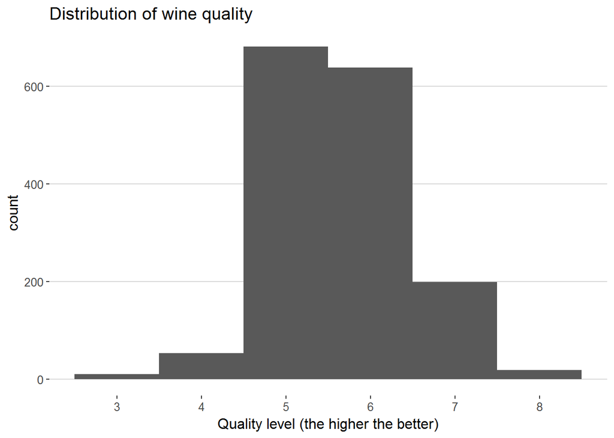

```
##    Min. 1st Qu.  Median    Mean 3rd Qu.    Max.
##   3.000   5.000   6.000   5.636   6.000   8.000
```

*Observations*

- Most of the wines have a medium quality: IQR = 1
- There are no wines of excellent quality. Max quality = 8
- There are no wines of very bad quality. Min quality = 3

### Freshness

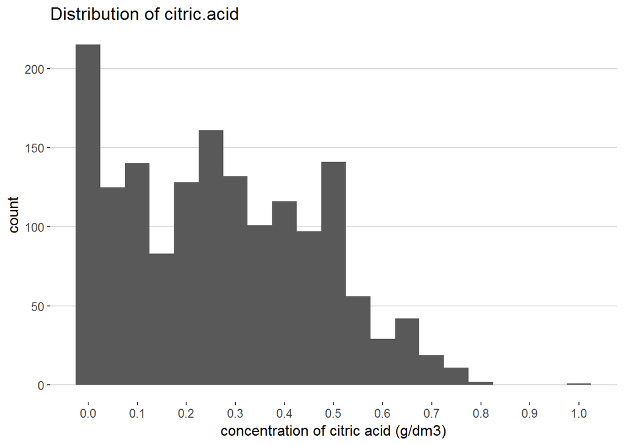

```
##    Min. 1st Qu.  Median    Mean 3rd Qu.    Max.
##   0.000   0.090   0.260   0.271   0.420   1.000
```

### Sweetness

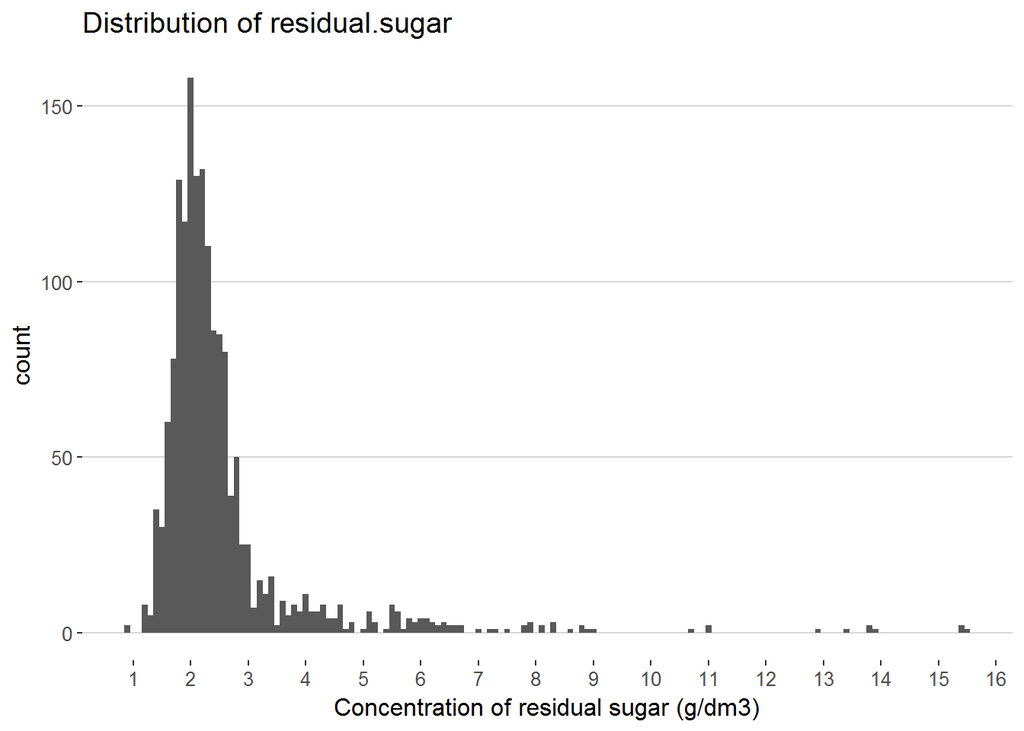

```
##    Min. 1st Qu.  Median    Mean 3rd Qu.    Max.
##   0.900   1.900   2.200   2.539   2.600  15.500
```

*Observations*  
Here the distribution is highly skewed (positevely). The Interquartile Range is quite small: 0.7 g/dm3.  
Although our median and mean are respectively 2.2 and 2.5 g/dm3, there are also wines which are more than 5 times sweeter: the max is 15.5 g/dm3.

### Salt

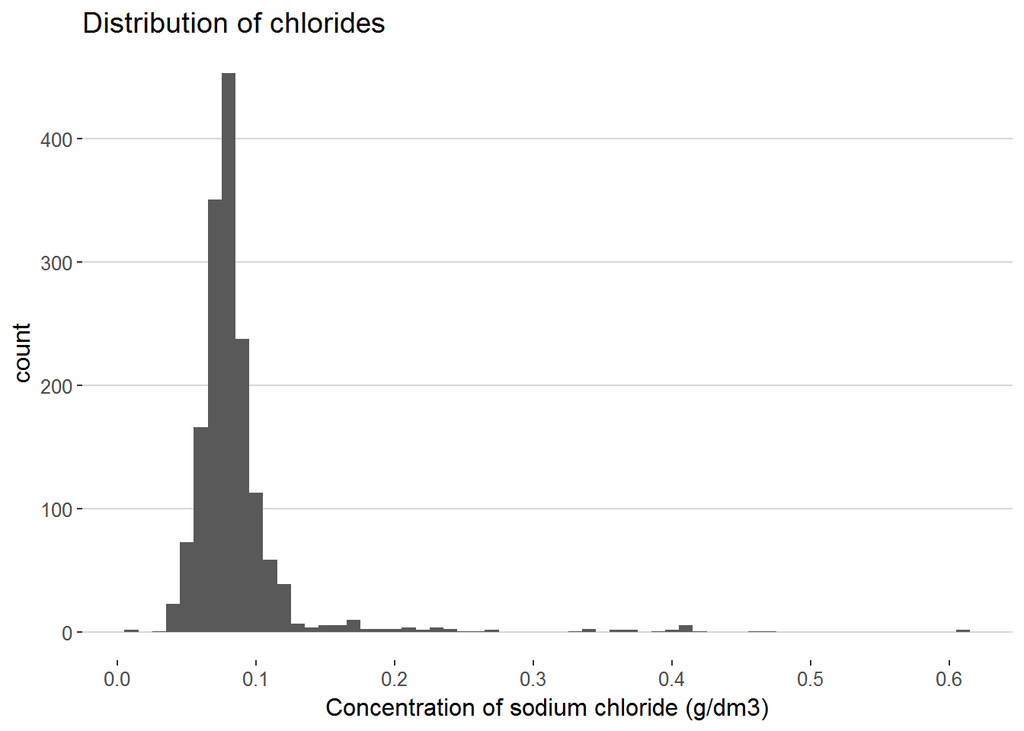

```
##    Min. 1st Qu.  Median    Mean 3rd Qu.    Max.
## 0.01200 0.07000 0.07900 0.08747 0.09000 0.61100
```

*Observations*  
This distribution has a shape similar to the previous distribution: very (postively) skewed.  
The IQR is also quite narrow: most of the wines have a chlorides concentration between 0.07 and 0.09 g/dm3.  
The “saltiest” wine in the sample has a chlorides concentration of 0.611 g/dm3.

### Alcohol volume

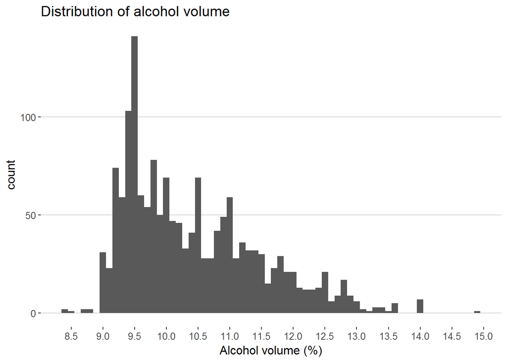

```
##    Min. 1st Qu.  Median    Mean 3rd Qu.    Max.
##    8.40    9.50   10.20   10.42   11.10   14.90
```

*Observations*  
This distribution is also positively skewed.  
Most wines have a alcohol volume between 9.5 and 11.1 (IQR).  
The mode is around 9.5%.  
No wines have less than 8.4% alcohol (min). This is doesn’t surprise me: to get the wine designation, the alcohol % can’t go lower than a certain value. [In France](https://fr.wikipedia.org/wiki/Vin) for instance, the minimum allowed is 8.5 %.

### Density

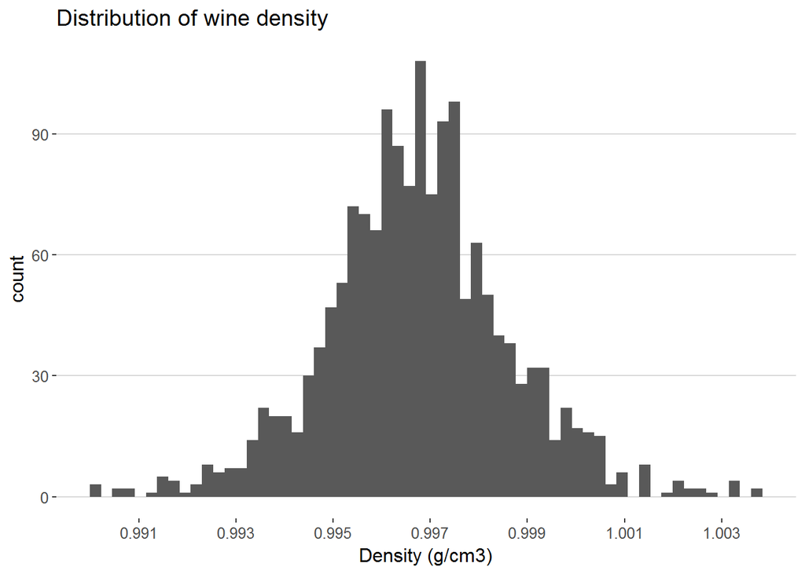

```
##    Min. 1st Qu.  Median    Mean 3rd Qu.    Max.
##  0.9901  0.9956  0.9968  0.9967  0.9978  1.0037
```

*Observations*  
The wine density distribution is normal, centered around 0.997 (g/cm3) with IQR=0.0022 (g/cm3).

### Fixed acidity

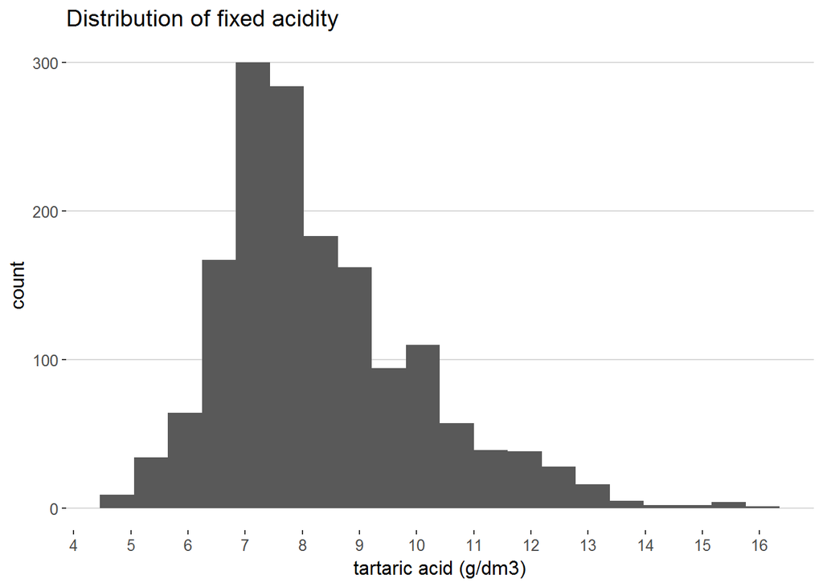

```
##    Min. 1st Qu.  Median    Mean 3rd Qu.    Max.
##    4.60    7.10    7.90    8.32    9.20   15.90
```

*Obervartions* Distribution close to a normal distribution, centered around 8, although not perfectly symetrical.

### Volatile acidity

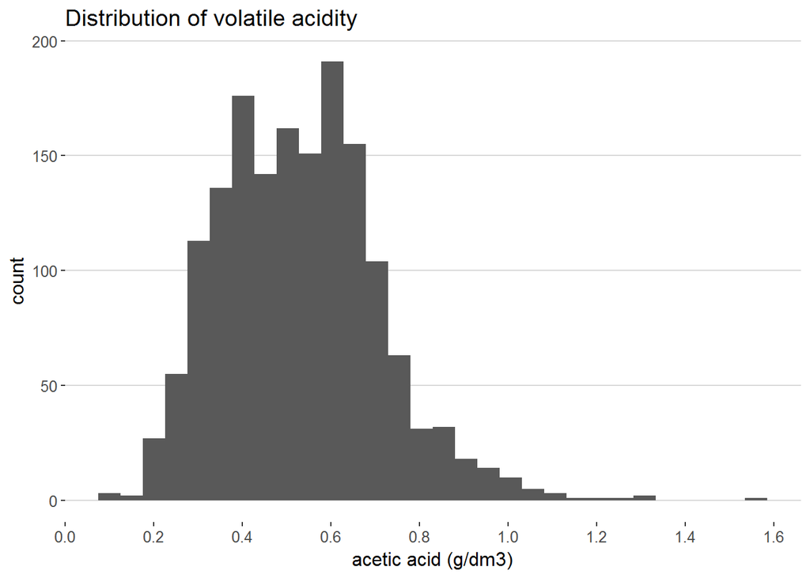

```
##    Min. 1st Qu.  Median    Mean 3rd Qu.    Max.
##  0.1200  0.3900  0.5200  0.5278  0.6400  1.5800
```

*Obervations*

### Free sulfur dioxide

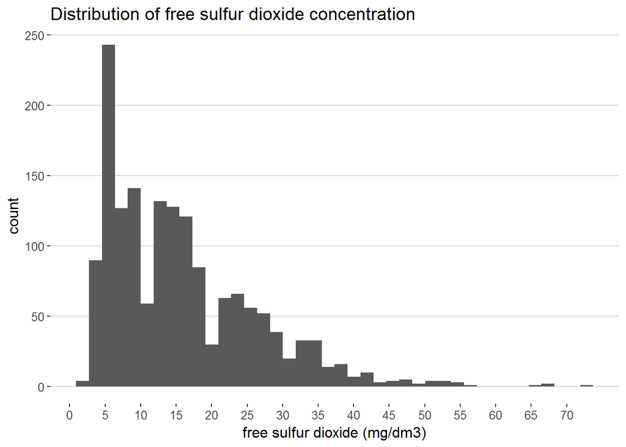

```
##    Min. 1st Qu.  Median    Mean 3rd Qu.    Max.
##    1.00    7.00   14.00   15.87   21.00   72.00
```

*Observations*

The distribution is skewed positevely. We see some clear “dips” along" the frequency though: e.g 10/20/30 mg/dm3.

### Total sulfur dioxide

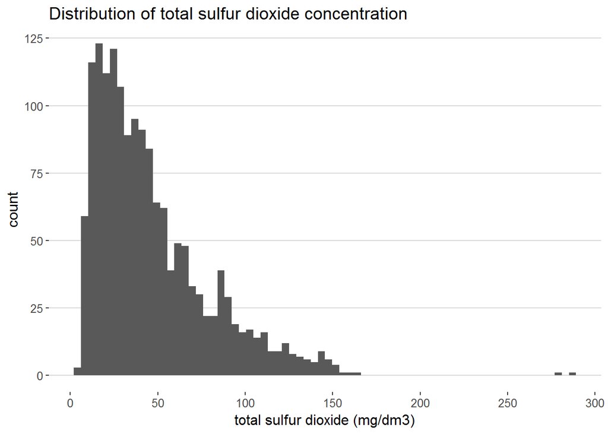

```
##    Min. 1st Qu.  Median    Mean 3rd Qu.    Max.
##    6.00   22.00   38.00   46.47   62.00  289.00
```

*Observations*

Distribution positevely skewed. We note some outliers which have a concentration more than 6 times more important than the mean concentration.

### pH

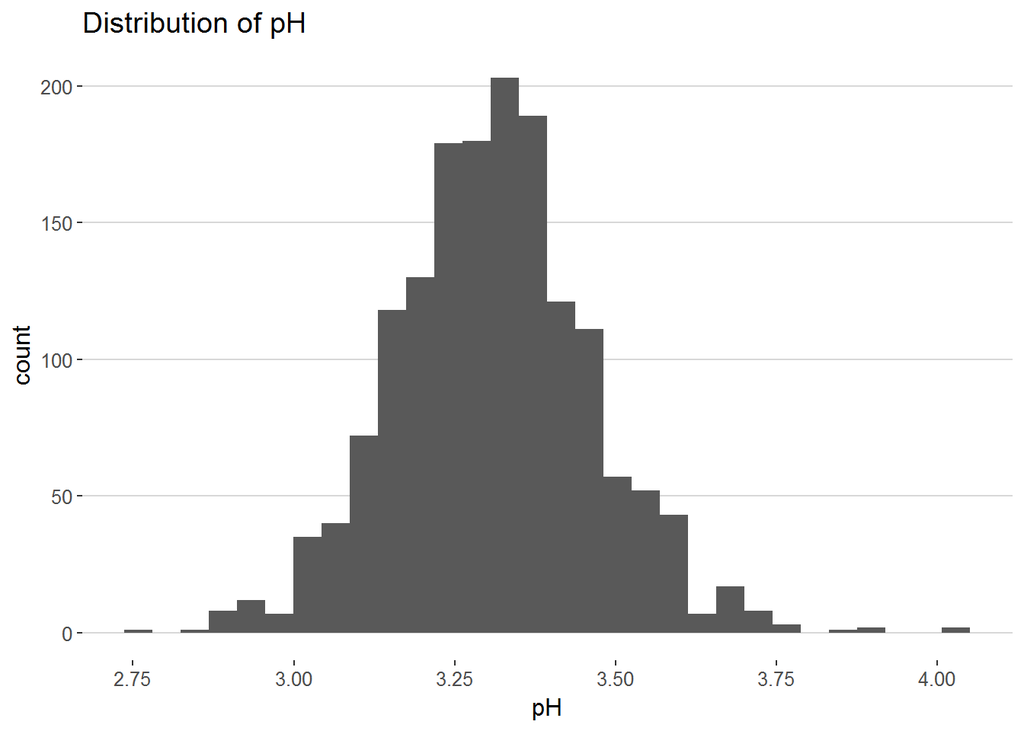

```
##    Min. 1st Qu.  Median    Mean 3rd Qu.    Max.
##   2.740   3.210   3.310   3.311   3.400   4.010
```

*Observations*

Distribution quite cose to a normal distributrion, centered around 3.3 and IQR close to 0.2.

### Sulphates

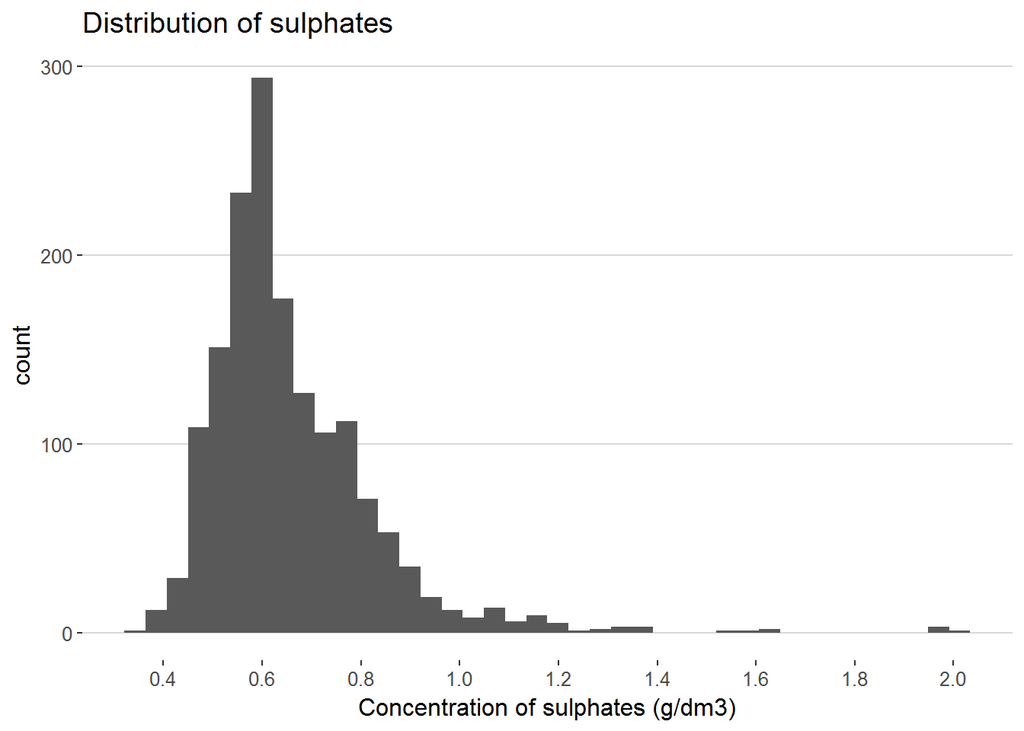

```
##    Min. 1st Qu.  Median    Mean 3rd Qu.    Max.
##  0.3300  0.5500  0.6200  0.6581  0.7300  2.0000
```

*Observations*

## Bivariate analysis

Due to the number of variables, let’s build first an exhaustive plots matrix using **ggpairs**.

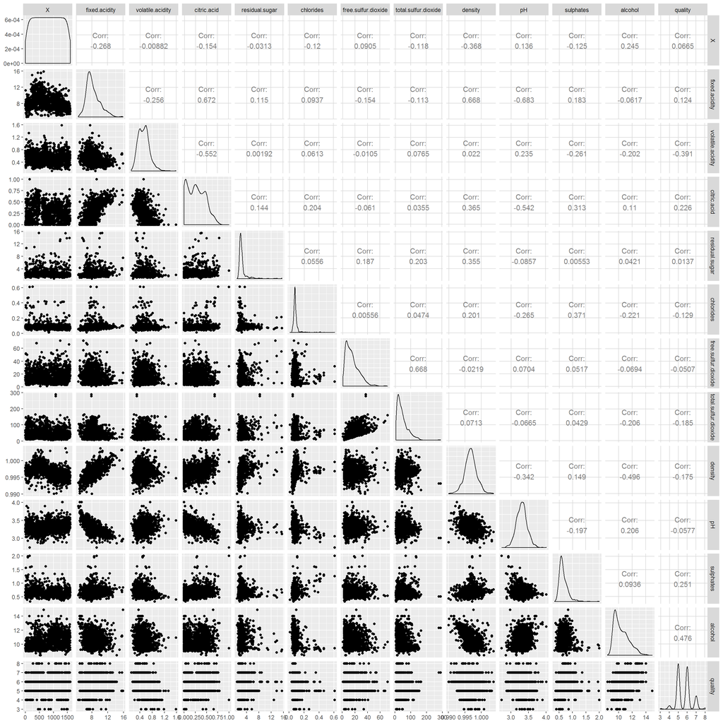

Out of these plots and correlations coeffcient, I note that the following couple variables are significantly correlated (abolsute value of correlation coefficient > 0.3):

- **Negatively:**
  - X and density  
    Not interesting, X doesn’t represent any wine property
  - pH and fixed acidity: -0.683 –> makes totally sense: [pH](https://en.wikipedia.org/wiki/PH) is a logarithmic scale to measure pH, 0 being the lowest.
  - volatile acidity and citric acid: -0.552
  - citric acid and pH: -0.542  
    High acids proportion (e.g citric acid) means high acidity means low pH.
  - densitiy and alcohol: -0.496  
    Alcohol or [ethanol](https://en.wikipedia.org/wiki/Ethanol) has a relatively low density or is quite “light”: 0.7893 g/cm3. Compared to~1g/cm3 for water. So the higher alcohol % volume, the lower the wine density.
  - density and pH: -0.342  
    pH is low because of the acids, which have a high density (see below).
- **Positively:**
  - density and fixed acidity: 0.668  
    Unlike ethanol the [tartaric acid](https://en.wikipedia.org/wiki/Tartaric_acid) is rather a “heavy” molecule, density 1.665 g/cm3. So the higher the higher the tartaric acid amount, the higher the acidity, the higher the density.
  - fixed acidity and citric acid: 0.672  
    Citric acid being an acid, this relationship is not surprising.
  - citric acid and sulphates: 0.313
  - citric acid and density: 0.365  
    Same explaination as for acidity/tartaric acid. [Citric acid](https://en.wikipedia.org/wiki/Citric_acid) has a density of 1.665 g/cm3.
  - residual sugar and density: 0.355  
    Same exaplaination as for the acids: sugar (both [glucose](https://en.wikipedia.org/wiki/Glucose) and [sucrose](https://en.wikipedia.org/wiki/Sucrose) have a density higher than 1.5 g/cm3, which is significantly higher than water density (~1 g/cm3).
  - chlorides and sulphates: 0.371
  - free and total sulfur dioxide  
    Altough I am not a chemist, I would say that this is no surprise, so i won’t consider this as an interesting finding.

To sum up, with regards to the variables I already analysed in the previous section, we can say that:

- citric acid “drives” acidity and pH
- they all “drive” density (although alcohol and citric acid/residual sugar in different directions)

Now some first questions that I will try to answer are:

1. Do good wines tend to be:
   - more or less sweet?
   - more or less fresh/bitter?
   - more or less salty?
2. Or are there both good and bad wines having a particular taste (sweet/fresh/salty)?
3. What is average alcohol volume of the best wines?
4. Are there any relationships between quality/density and one of my selected variable?

### Freshness vs quality

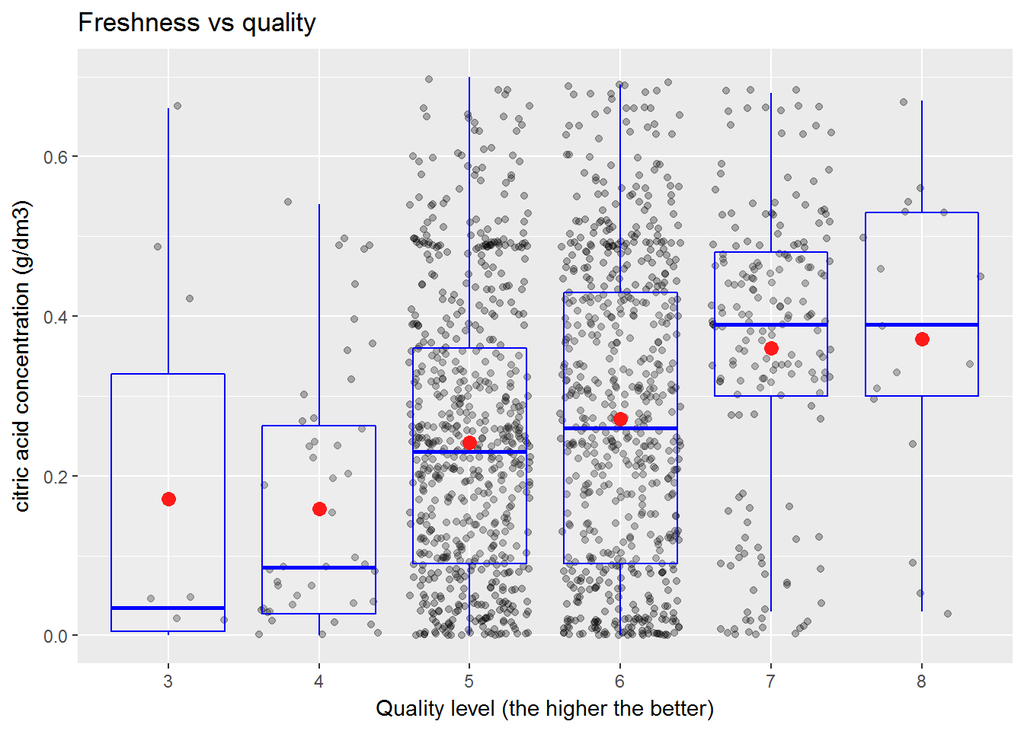

*Observations*  
Although the overplotting makes difficult to see any trends, thanks to visualising the mean per quality levels and overlaying boxplots, we can say that in average, the better the quality the higher the wine ‘freshness’ level (citric acid concentration). The high variance on all levels of quality is also clearly visible. We note also the asymetry of the quality level distribution (small median/Q3 ratio).

### Sweetness vs quality

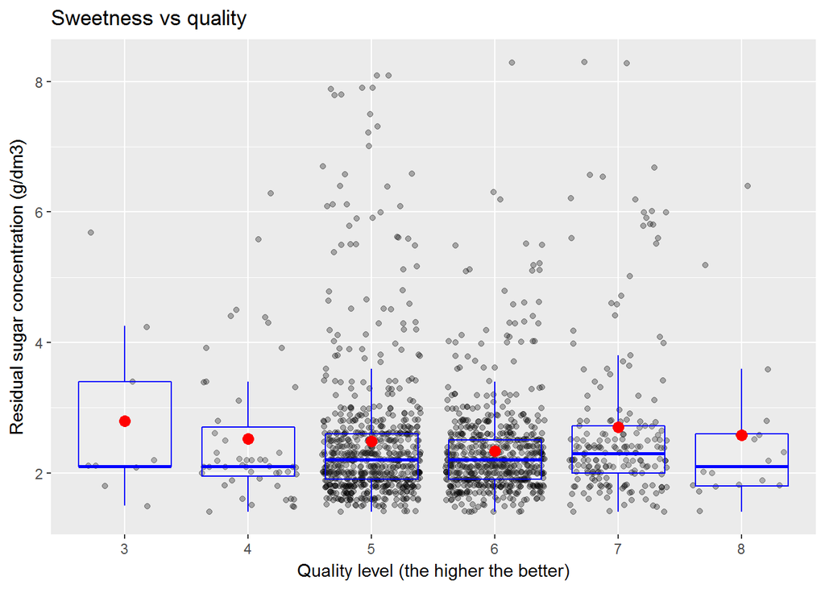

*Observations*  
On the other hand, the quality doesn’t seem to be dependent on the level of sugar. The average residual sugars concentration remains constant no matter the quality. So there are both both “good” and “bad” sweet wines.  
I also note that the distribution of quality level 3 is very asymetric: around 1.5 g/dm3 difference between median and Q3 and median=Q1. We note also a high number of outliers, especially for the quality level 5.

### Salt vs quality

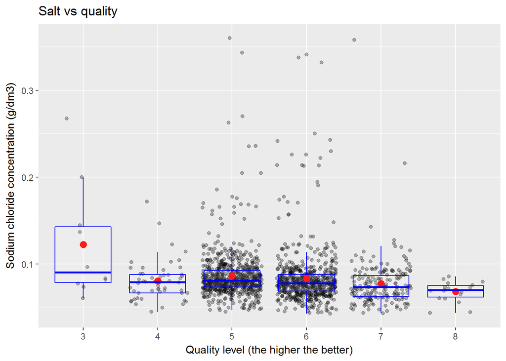

*Observations*  
Here the trend is that, in average, better wines tend to have a smaller concentration of salt. In my opinion it makes sense, when it comes to drinks, few people like to drink something salty!  
We see lot of outliers for medium quality wines. The dispersion is higher for low quality wines than for high quality wines.

### Alcohol volume vs quality

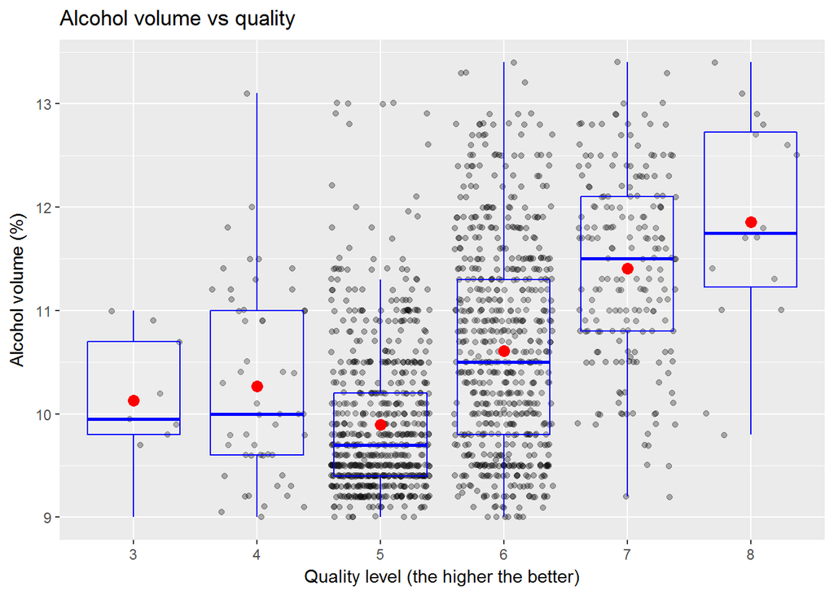

*Observations*  
Here despite the decrease for medium quality, I can also see a clear trend: better quality wine tend to have, in average, a higher volume of alcohol.  
We see again lot of outliers for medium quality wines (quality 5). The quality 3 wines distribution is again quite asymetric (low ratio median/Q3).

### Density vs quality

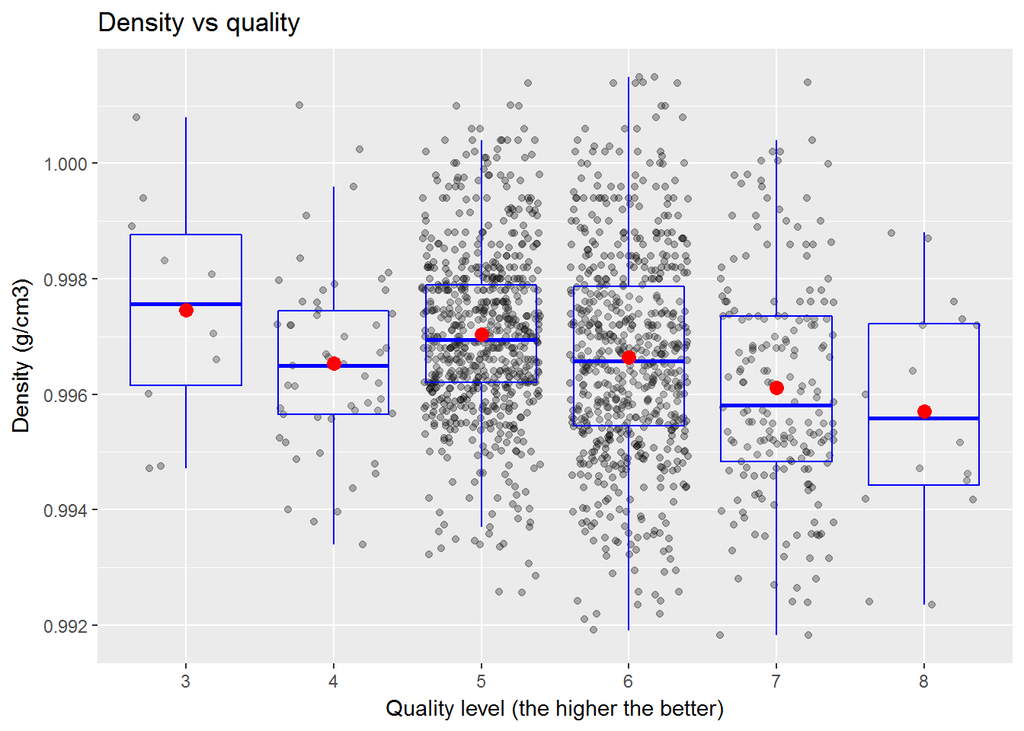

*Observations*  
In average better wines tend to have a lower density.  
Again lot of outliers for medium quality wines (quality 5). For all quality levels, the distributions are rather symetric.

##Multivariate Analysis  
To support the multivariate analysis, let’s group the quality levels and visualize the different quality group with a different color:

- low: quality levels 3
- medium: quality levels 4, 5 and 6
- high: quality levels 7 and 8

```r
wine$quality.levels <- cut(wine$quality, breaks=c(2.9, 3.1, 6.1, 8.1),
                           include.lowest = T,
                           labels=c('Low', 'Medium', 'High'))
```

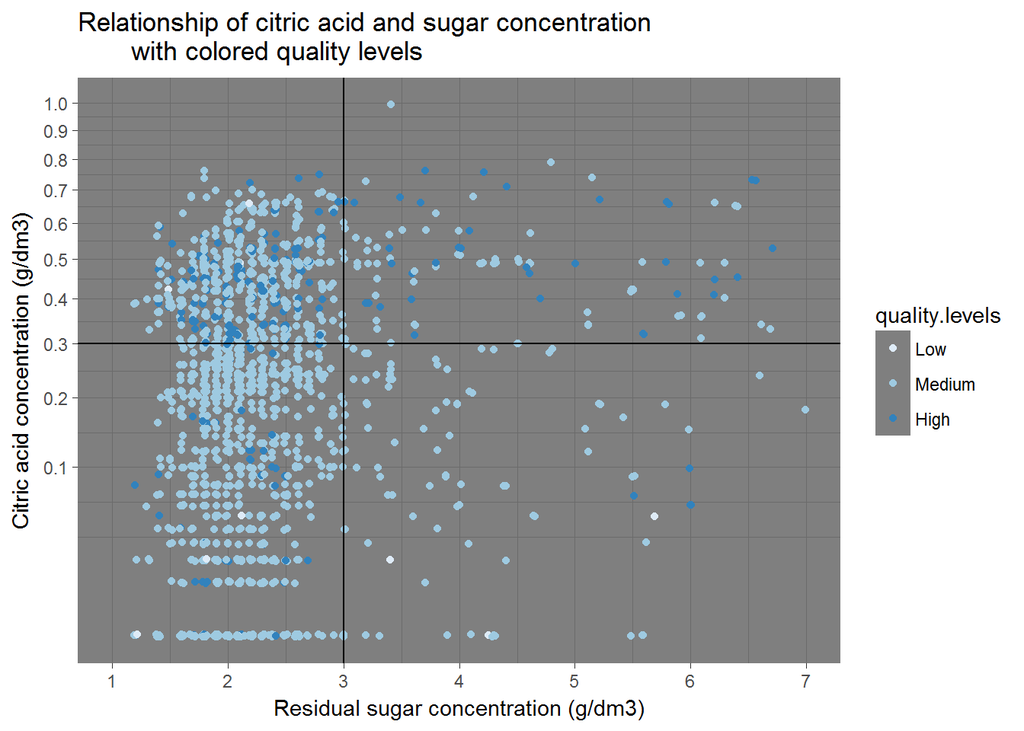

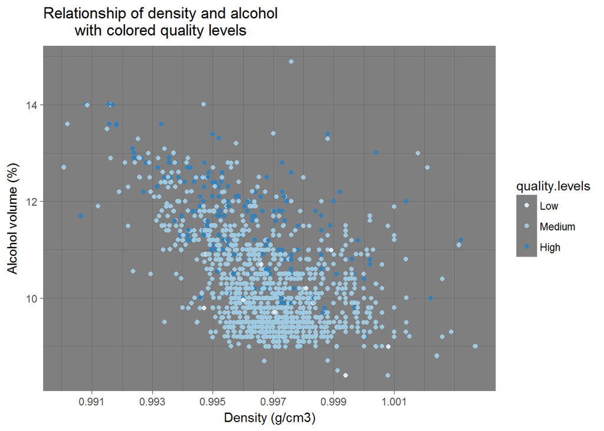

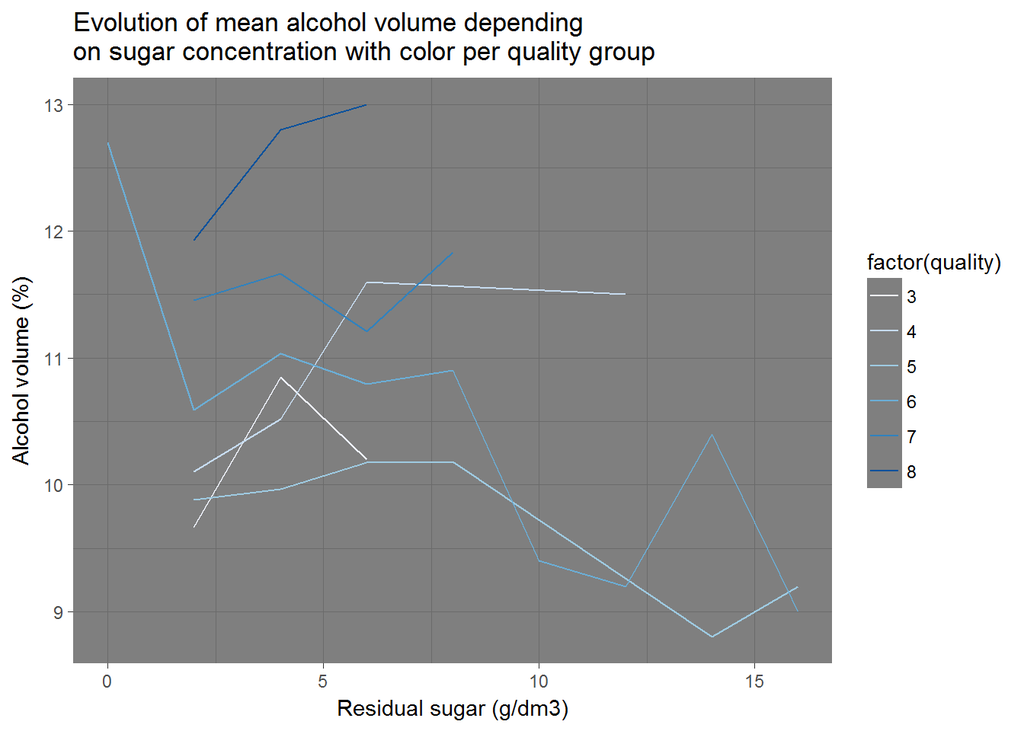

*Observations*  
Based on these plots, we see for instance that to get good quality wines (8), the alcohol volume increases together with the sugar concentration.

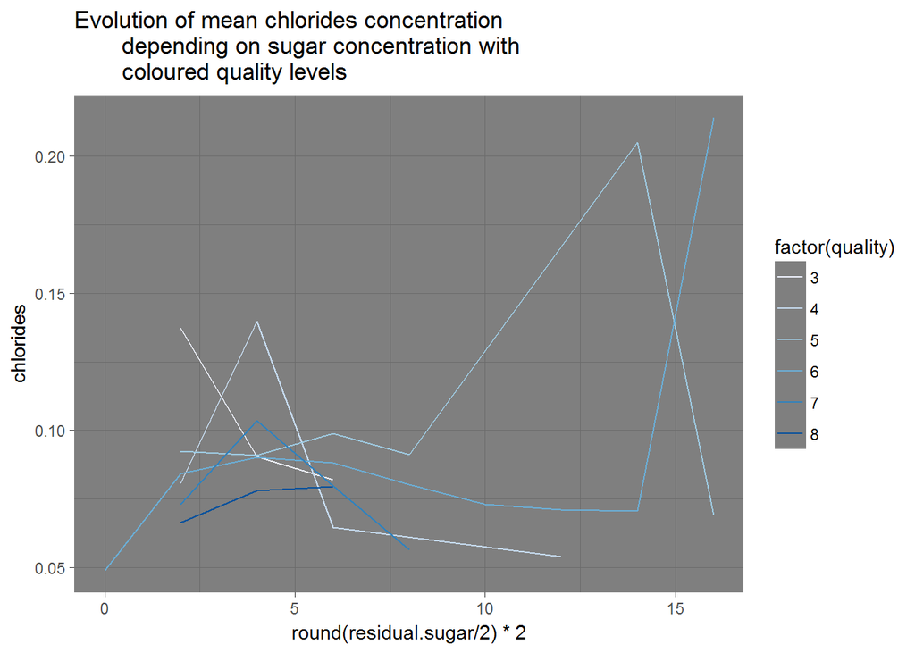

*Observations*  
Looking at the extreme opposites (quality levels 3 and 8), we see that the relationships are opposite: in average the chlorides concentration would increase together with the sugar concentration for a high quality wine, while it would decrease for a bad quality wine.

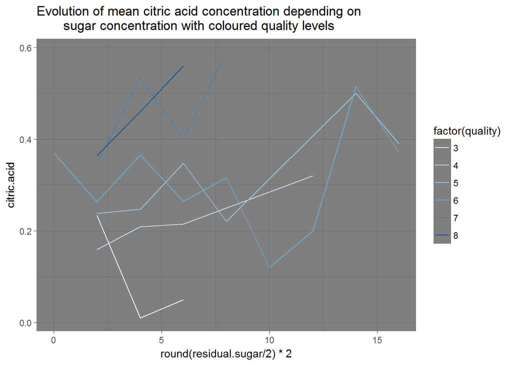

*Observations*  
Looking again at the extreme opposites (quality levels 3 and 8), we see that the relationships are also opposite: in average the citric acid concentration would increase together with the sugar concentration for a high quality wine, while it would decrease for a bad quality wine.

## Summary

### Final Plots

#### Salt

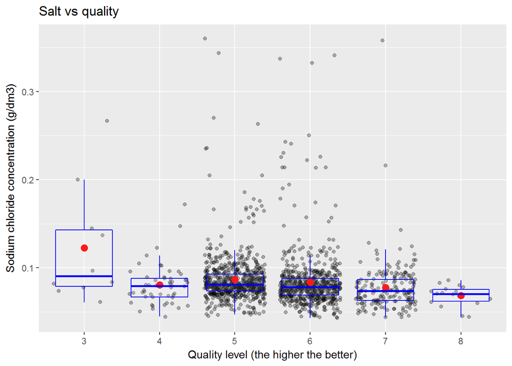

*Finding 1*  
Reading this plot one conclusion is clear: good wines don’t taste salty!

#### Linear relationship between density and alcohol volume

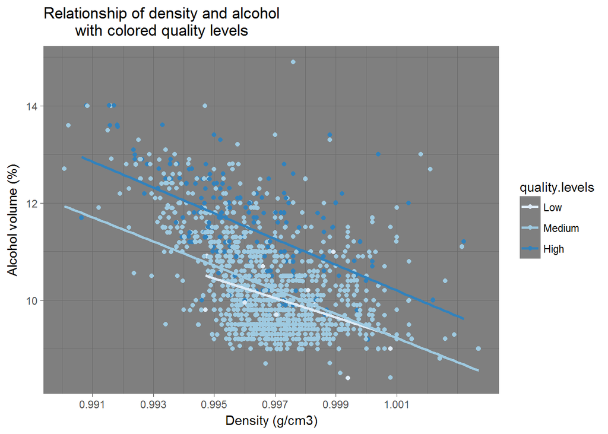

*Finding 2*  
The density decreases linearly with alcohol volume. And better wines have a higher alcohol concentration.

#### Relationship between citric acid and sugar concentration depending on quality levels

```
## 'data.frame':    1599 obs. of  14 variables:
##  $ X                   : int  1 2 3 4 5 6 7 8 9 10 ...
##  $ fixed.acidity       : num  7.4 7.8 7.8 11.2 7.4 7.4 7.9 7.3 7.8 7.5 ...
##  $ volatile.acidity    : num  0.7 0.88 0.76 0.28 0.7 0.66 0.6 0.65 0.58 0.5 ...
##  $ citric.acid         : num  0 0 0.04 0.56 0 0 0.06 0 0.02 0.36 ...
##  $ residual.sugar      : num  1.9 2.6 2.3 1.9 1.9 1.8 1.6 1.2 2 6.1 ...
##  $ chlorides           : num  0.076 0.098 0.092 0.075 0.076 0.075 0.069 0.065 0.073 0.071 ...
##  $ free.sulfur.dioxide : num  11 25 15 17 11 13 15 15 9 17 ...
##  $ total.sulfur.dioxide: num  34 67 54 60 34 40 59 21 18 102 ...
##  $ density             : num  0.998 0.997 0.997 0.998 0.998 ...
##  $ pH                  : num  3.51 3.2 3.26 3.16 3.51 3.51 3.3 3.39 3.36 3.35 ...
##  $ sulphates           : num  0.56 0.68 0.65 0.58 0.56 0.56 0.46 0.47 0.57 0.8 ...
##  $ alcohol             : num  9.4 9.8 9.8 9.8 9.4 9.4 9.4 10 9.5 10.5 ...
##  $ quality             : int  5 5 5 6 5 5 5 7 7 5 ...
##  $ quality.levels      : Factor w/ 3 levels "Low","Medium",..: 2 2 2 2 2 2 2 3 3 2 ...
```

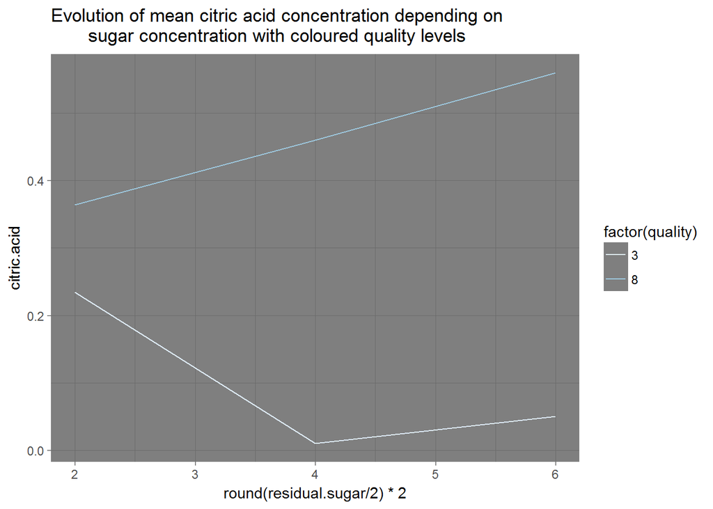

*Finding 3*  
Depending on the wine quality, the critical acid concentration moves in clearly opposite direction when the sugar concentration increases:

- good wines contains more citric acid when they get sweeter
- bad wines contains less citric acid when they get sweeter

I would interpret this as a sign that good wines have to be “balanced”: the more sugar, the more citric acid, so that the taste doesn’t get dominated by a sweet note.  
On the opposite a bad wine could be qualified as such precisely because one taste note like sweetness dominates all the others.